# Analysis example

Clay Ford

2024-08-19

## Simulate data

Below I simulate data with 2-way and 3-way interactions and a random intercept. The total sample size is 200 with 50 observations per group (`univ`).

```r
# simulate predictors
set.seed(1)
n <- 200 # total sample size
g <- 4   # number of groups
univ <- gl(n = g, k = n/4)
x1 <- factor(sample(0:1, size = n, replace = TRUE))
x2 <- factor(sample(letters[1:g], size = n, replace = TRUE))
p <- round(runif(n), 2)

# simulate noise
e <- rnorm(n, mean = 0, sd = 0.1) # within groups (Residual)
z <- rnorm(g, mean = 0, sd = 0.1) # between groups (Intercept)

# simulate outcome
y <- (0.2 + z[univ]) + 0.5 * p +
  0.4 * (x1 == "1") +
  -0.2 * (x2 == "b") + 0.2 * (x2 == "c") + 0.4 * (x2 == "d") +
  # 2 way interactions
  -0.3 * p * (x1 == "1") +
  0.3 * p * (x2 == "b") + 0.5 * p * (x2 == "c") + 0.1 * p * (x2 == "d") +
  -0.2 * (x1 == "1") * (x2 == "b") +
  0.2 * (x1 == "1") * (x2 == "c") +
  0.4 * (x1 == "1") * (x2 == "d") +
  # 3 way interactions
  0.7 * p * (x1 == "1") * (x2 == "b") +
  0.5 * p * (x1 == "1") * (x2 == "c") +
  -0.5 * p * (x1 == "1") * (x2 == "d") + e

# combine into data frame
d <- data.frame(y, x1, x2, p, univ)
summary(d)
```

```
##        y            x1      x2           p          univ
##  Min.   :-0.09062   0:102   a:58   Min.   :0.0000   1:50
##  1st Qu.: 0.50811   1: 98   b:48   1st Qu.:0.2900   2:50
##  Median : 0.78409           c:41   Median :0.5150   3:50
##  Mean   : 0.83211           d:53   Mean   :0.5194   4:50
##  3rd Qu.: 1.14042                  3rd Qu.:0.7600
##  Max.   : 2.26147                  Max.   :1.0000
```

This is not quite like your data but allows me to demonstrate the {ggeffects} and {emmeans} packages.

## Fit the model

This is the correct model to fit since this is the model we used to simulate the data.

```r
library(rstanarm)
m <- stan_lmer(y ~ p * x1 * x2 + (1|univ), data = d, refresh = 0)
```

The model coefficients are pretty similar to the “true” values we used to simulate the data.

```r
m
```

```
## stan_lmer
##  family:       gaussian [identity]
##  formula:      y ~ p * x1 * x2 + (1 | univ)
##  observations: 200
## ------
##             Median MAD_SD
## (Intercept)  0.2    0.1
## p            0.5    0.1
## x11          0.3    0.1
## x2b         -0.2    0.1
## x2c          0.1    0.1
## x2d          0.3    0.1
## p:x11       -0.1    0.1
## p:x2b        0.3    0.1
## p:x2c        0.6    0.1
## p:x2d        0.2    0.1
## x11:x2b     -0.2    0.1
## x11:x2c      0.3    0.1
## x11:x2d      0.5    0.1
## p:x11:x2b    0.7    0.1
## p:x11:x2c    0.3    0.2
## p:x11:x2d   -0.7    0.1
##
## Auxiliary parameter(s):
##       Median MAD_SD
## sigma 0.1    0.0
##
## Error terms:
##  Groups   Name        Std.Dev.
##  univ     (Intercept) 0.10
##  Residual             0.11
## Num. levels: univ 4
##
## ------
## * For help interpreting the printed output see ?print.stanreg
## * For info on the priors used see ?prior_summary.stanreg
```

Effect plots and estimated marginal means allow us to dig deeper.

## Effect plots

Effect plots visualize the model. The {ggeffects} package makes this fairly easy to do.

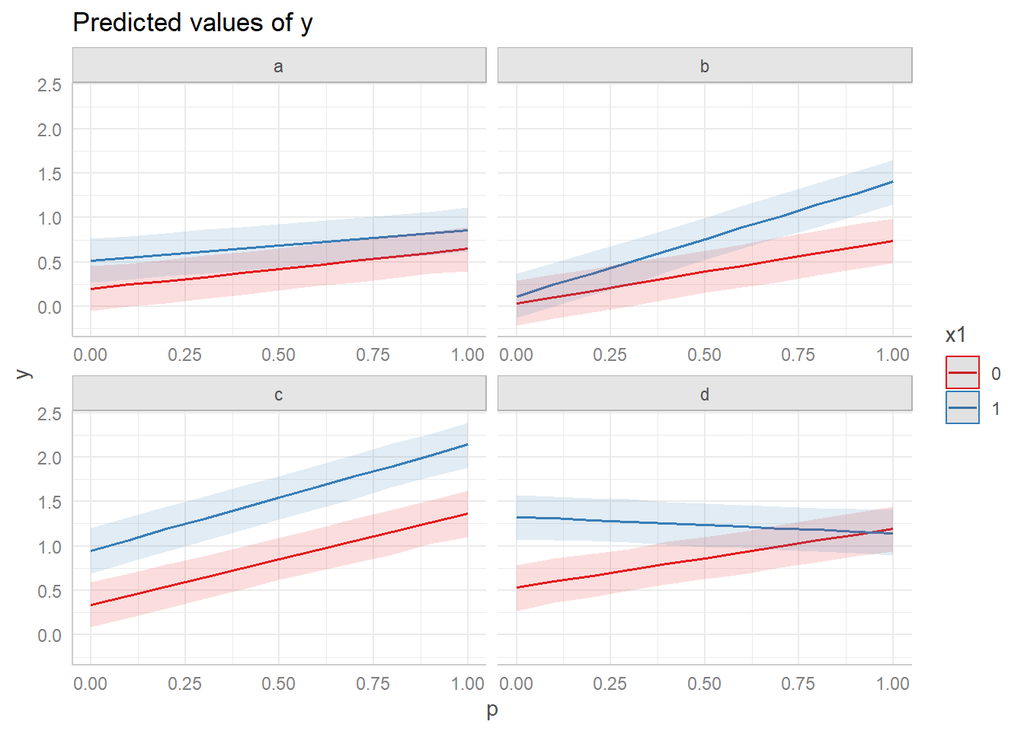

```r
library(ggeffects)
ggpredict(m, terms = c("p", "x1", "x2"), interval = "prediction") |> plot()
```

This plot helps us understand the nature of the interactions. For example, in lower right plot, when `x2` = “d” and `x1` = 0, the effect of `p` is *positive* (red line). But when `x2` = d and `x1` = 1, the effect of `p` is *slightly negative* (blue line). This demonstrates why we should be careful about interpreting the main effect of `p` in the presence of interactions.

## Marginal effects

The plot above shows the slope (ie, effect) of `p` differing depending on `x1` and `x2`, especially in the lower right plot. But how can we quantify that difference? We can use the `emtrends()` function from the {emmeans} package to help answer this.

```r
library(emmeans)
emtrends(m, ~ x1 | x2, var = "p")
```

```
## x2 = a:
##  x1 p.trend lower.HPD upper.HPD
##  0    0.453     0.326    0.5782
##  1    0.346     0.197    0.4747
##
## x2 = b:
##  x1 p.trend lower.HPD upper.HPD
##  0    0.707     0.547    0.8812
##  1    1.284     1.137    1.4352
##
## x2 = c:
##  x1 p.trend lower.HPD upper.HPD
##  0    1.025     0.846    1.1954
##  1    1.195     1.021    1.3725
##
## x2 = d:
##  x1 p.trend lower.HPD upper.HPD
##  0    0.654     0.515    0.8059
##  1   -0.179    -0.318   -0.0324
##
## Point estimate displayed: median
## HPD interval probability: 0.95
```

If we like, we can quantify the difference in slopes by piping the result into the `emmeans::pairs()` function:

```r
emtrends(m, ~ x1 | x2, var = "p")  |> pairs()
```

```
## x2 = a:
##  contrast  estimate lower.HPD upper.HPD
##  x10 - x11    0.109   -0.0868    0.2836
##
## x2 = b:
##  contrast  estimate lower.HPD upper.HPD
##  x10 - x11   -0.578   -0.7985   -0.3517
##
## x2 = c:
##  contrast  estimate lower.HPD upper.HPD
##  x10 - x11   -0.171   -0.4324    0.0842
##
## x2 = d:
##  contrast  estimate lower.HPD upper.HPD
##  x10 - x11    0.834    0.6371    1.0477
##
## Point estimate displayed: median
## HPD interval probability: 0.95
```

This tells us the difference in slopes (ie, difference in the `p` coefficient) is about 0.834 [0.637, 1.047].

All of this can be done in a Frequentist framework as well.

## References

- Lüdecke D (2018). “ggeffects: Tidy Data Frames of Marginal Effects from Regression Models.” *Journal of Open Source Software*, *3*(26),
  772. doi:10.21105/joss.00772 https://doi.org/10.21105/joss.00772.
- Lenth R (2024). *emmeans: Estimated Marginal Means, aka Least-Squares Means*. R package version 1.10.3, https://CRAN.R-project.org/package=emmeans.

## Computational details

```r
sess <- sessionInfo()
sess$R.version$version.string
```

```
## [1] "R version 4.4.1 (2024-06-14 ucrt)"
```

```r
sess$running
```

```
## [1] "Windows 10 x64 (build 19045)"
```

```r
packageVersion("ggeffects")
```

```
## [1] '1.7.0'
```

```r
packageVersion("emmeans")
```

```
## [1] '1.10.3'
```

```r
packageVersion("rstanarm")
```

```
## [1] '2.32.1'
```